# Adopción de IPv6 en Países de la Región

## Resumen ejecutivo: Adopción de IPv6 en Mexico

El presente documento muestra el nivel de adopción de IPv6 por parte de proveedores de Internet de Mexico estimado a través de comportamientos observables externamente.

Los datos presentados corresponden al **20170810**.

## Breve descripción de la metodología de medición

Los operadores de red o prestadores de servicios se identifican mediante sus números de sistema autónomo (ASN). Los números de ASN constituyen un identificador único de un operador en Internet.

Los datos presentados aquí son relevados por un sistema de mediciones elaborado por investigadores de APNIC (El RIR de la región de Asia-Pacífico). El mecanismo de la medición consiste en presentar a los usuarios contenido web con algunos elementos alcanzables únicamente por IPv6, otros alcanzables por ambos protocolos y otros solo por IPv4. De esta manera es posible clasificar la capacidad de utilizar IPv6 por parte de un usuario en dos grandes conjuntos:

- “IPv6 Capable”: el usuario tiene la posibilidad de utilizar IPv6 para alcanzar ciertos contenidos
- “IPv6 Preferred”: el usuario no solo tiene la posibilidad de utilizar IPv6 sino que en caso de poder usar tanto IPv4 como IPv6, **prefiere IPv6**

Idealmente todos los usuarios deberían caer en este último conjunto. Sin embargo, por diferentes motivos existen casos donde los usuarios pueden utilizar IPv6 pero no lo prefieren.

Conviene destacar que esta preferencia no es controlada por el usuario sino que es el resultado de las características de la red y del software de cada usuario.

APNIC utiliza Google AdWords como el vehículo por el cual se logra la presentación de estos contenidos web a los usuarios en grandes cantidades y distribuidos geográficamente de una manera relativamente uniforme.

Esta metodología de medición si bien resulta extremadamente útil también tiene ciertas limitaciones, entre ellas, a saber:

- Tiende a sub-estimar la penetración de IPv6 a nivel de operadores móviles, debido a la forma que los navegadores de smartphones presentan los AdWords al usuario
- Puede sub-estimar la penetración IPv6 en redes donde por alguna razón los AdWords son filtrados o alterados de alguna forma por el operador mismo
- Hay un cierto sesgo que se introduce debido a la forma en la que se distribuyen a lo largo del día las impresiones de los AdWords

## Mediciones en Mexico: Adopción de IPv6

- Tabla I: “Top 10” de operadores de Mexico ordenados de acuerdo a la actividad detectada (cantidad de muestras)

**Observación**: La cantidad de muestras es proporcional al tamaño y cantidad de usuarios de cada operador. Cuantas más muestras se observan, mayor es la cantidad de usuarios que tiene el operador.

```
##      ASN                            ORG_NAME IPv6Cap IPv6Pref SAMPLES
## 1   8151                 Uninet S.A. de C.V.  6.8043   6.5543 1614624
## 2  13999            Mega Cable, S.A. de C.V.  0.0087   0.0087  360517
## 3  28548           Cablevisión, S.A. de C.V.  0.0000   0.0000  154166
## 4  17072 TOTAL PLAY TELECOMUNICACIONES SA DE  0.0000   0.0000  131005
## 5  11888 Television Internacional, S.A. de C  0.0112   0.0068  111921
## 6  28509 Cablemas Telecomunicaciones SA de C  0.0000   0.0000  100415
## 7   6503               Axtel, S.A.B. de C.V.  0.0052   0.0035   69682
## 8  28554 Cablemas Telecomunicaciones SA de C  0.0000   0.0000   53872
## 9  28403      RadioMovil Dipsa, S.A. de C.V.  0.0116   0.0000   53332
## 10 28545 Cablemas Telecomunicaciones SA de C  0.0060   0.0060   45078
```

La columna de cantidad de muestras de alguna manera indica el tamaño del operador en cantidad de usuarios. Cuanto mayor es este valor quiere decir que mayor es la base de usuarios a la que Google le presenta sus AdWords.

## Actividad IPv6 en los Top10

A continuación se muestra la actividad IPv6 para los operadores Top 10 de Mexico. En cada caso se grafican los datos del último año y se muestran los promedios para el último año y los últimos 30 días.

## Actividad para el ASN 8151

- Nombre organización: **Uninet S.A. de C.V.**
- Promedio de actividad IPv6 ultimos 30 dias: 10.4357142857143 %
- Máximo de actividad IPv6 ultimos 30 dias: 12.89 %
- Promedio de actividad IPv6 ultimos 360 dias: 0.687105263157895 %
- Máximo de actividad IPv6 ultimos 360 dias: 12.89 %

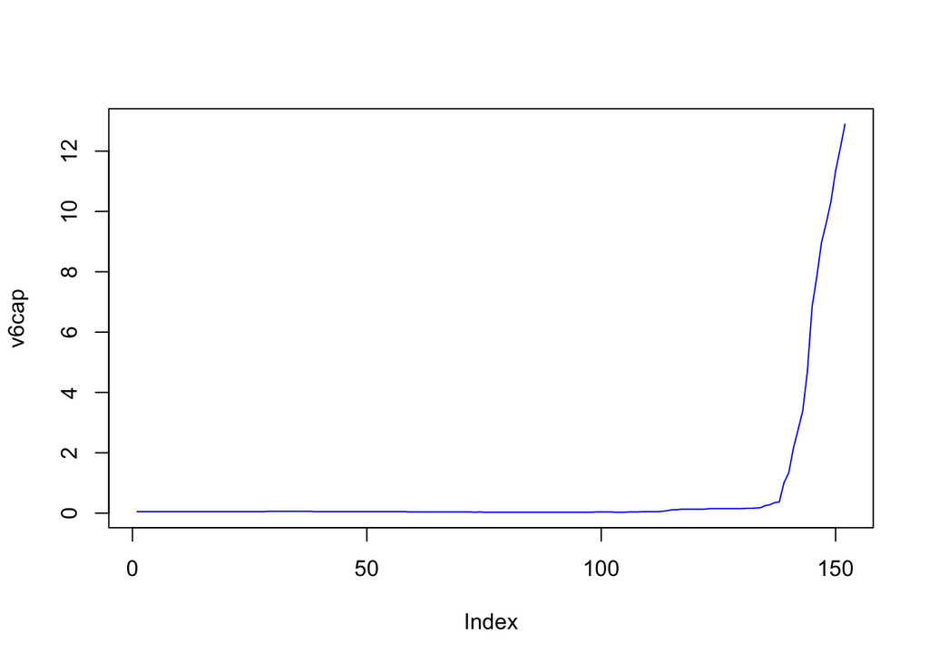

## Actividad para el ASN 13999

- Nombre organización: **Mega Cable, S.A. de C.V.**
- Promedio de actividad IPv6 ultimos 30 dias: 0.01 %
- Máximo de actividad IPv6 ultimos 30 dias: 0.01 %
- Promedio de actividad IPv6 ultimos 360 dias: 0.00402877697841727 %
- Máximo de actividad IPv6 ultimos 360 dias: 0.07 %

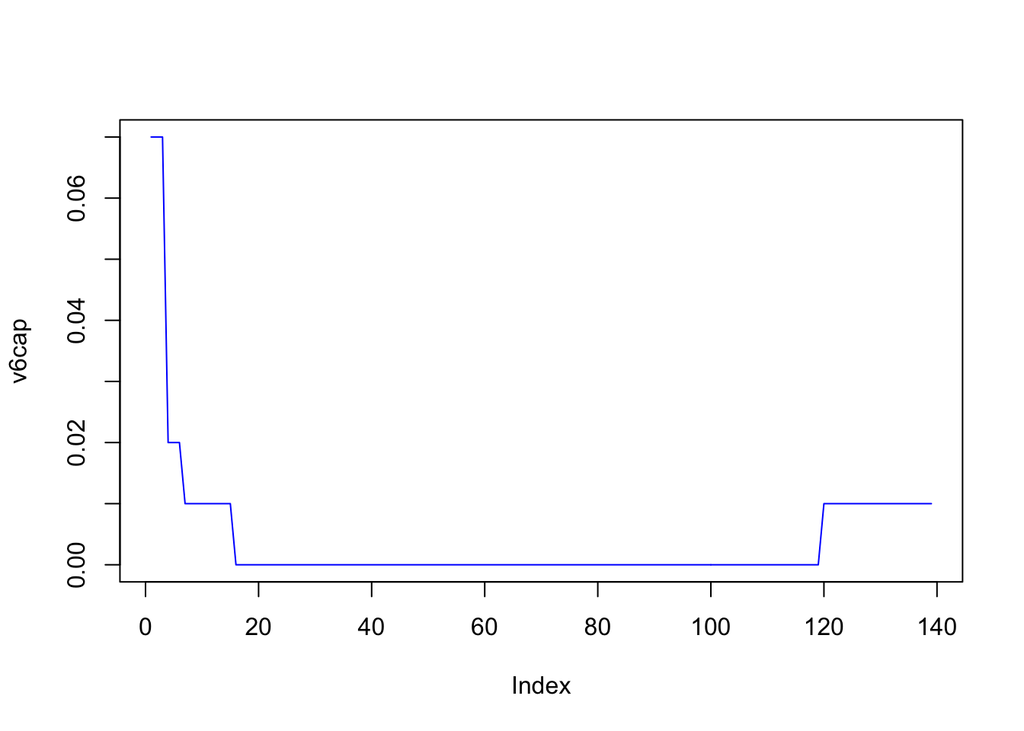

## Actividad para el ASN 28548

- Nombre organización: **Cablevisión, S.A. de C.V.**
- Promedio de actividad IPv6 ultimos 30 dias: 0 %
- Máximo de actividad IPv6 ultimos 30 dias: 0 %
- Promedio de actividad IPv6 ultimos 360 dias: 0 %
- Máximo de actividad IPv6 ultimos 360 dias: 0 %

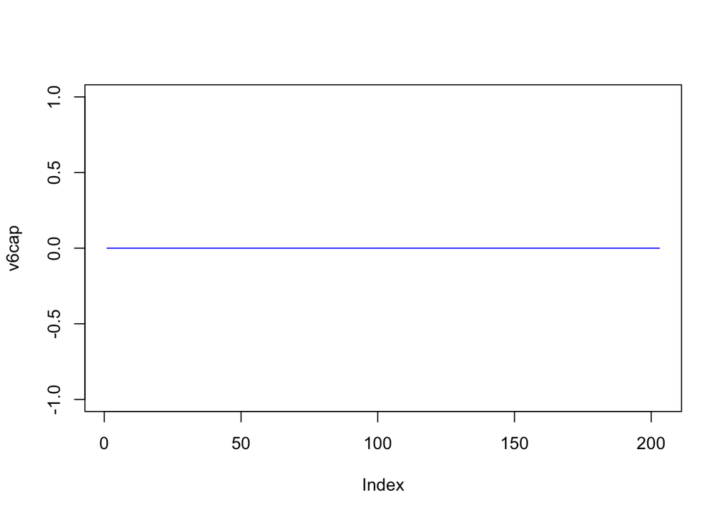

## Actividad para el ASN 17072

- Nombre organización: **TOTAL PLAY TELECOMUNICACIONES SA DE**
- Promedio de actividad IPv6 ultimos 30 dias: 0 %
- Máximo de actividad IPv6 ultimos 30 dias: 0 %
- Promedio de actividad IPv6 ultimos 360 dias: 0.000714285714285714 %
- Máximo de actividad IPv6 ultimos 360 dias: 0.01 %

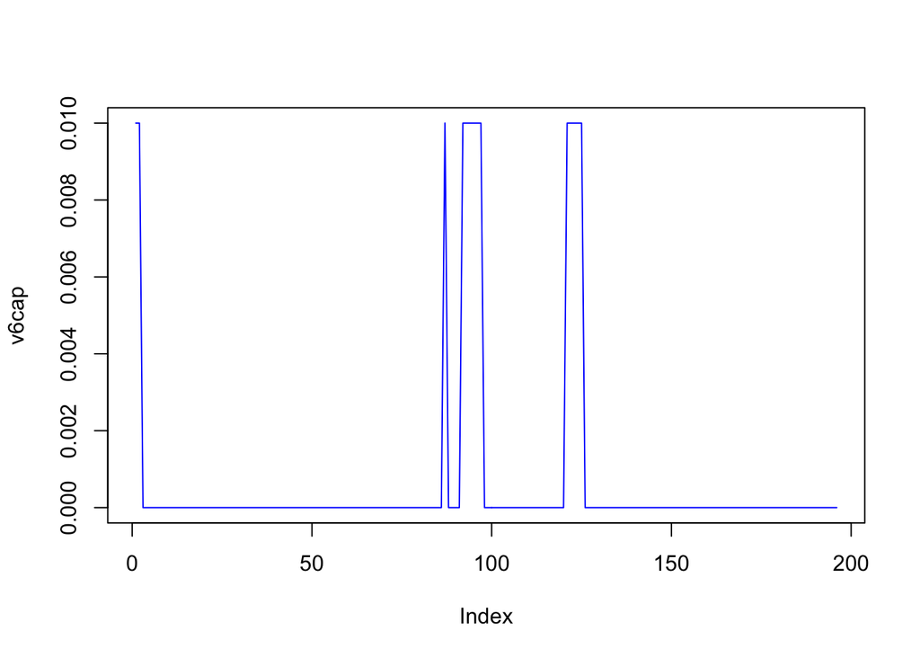

## Actividad para el ASN 11888

- Nombre organización: **Television Internacional, S.A. de C**
- Promedio de actividad IPv6 ultimos 30 dias: 0.02 %
- Máximo de actividad IPv6 ultimos 30 dias: 0.02 %
- Promedio de actividad IPv6 ultimos 360 dias: 0.00561855670103093 %
- Máximo de actividad IPv6 ultimos 360 dias: 0.02 %

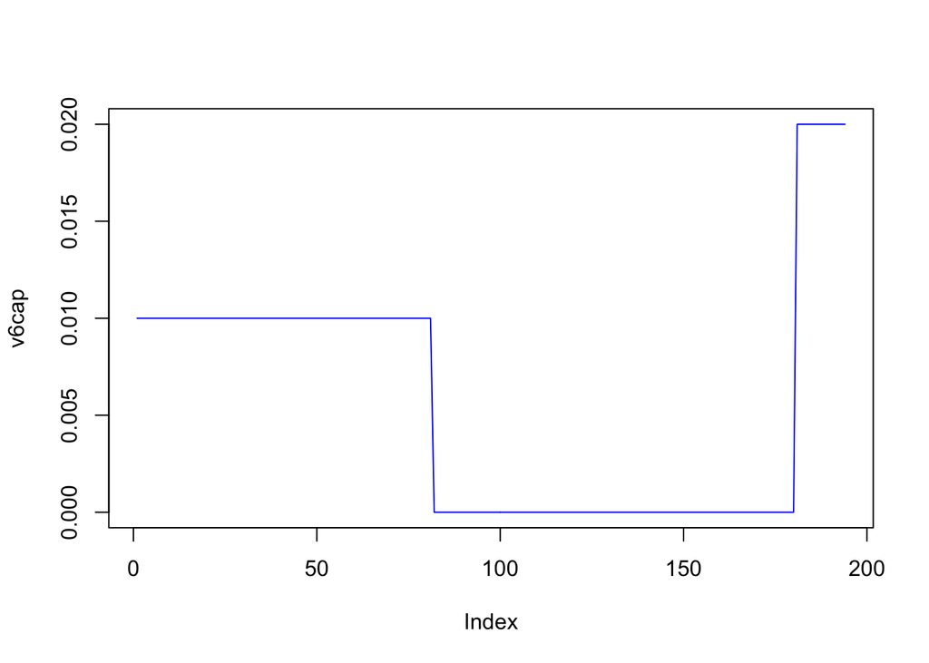

## Actividad para el ASN 28509

- Nombre organización: **Cablemas Telecomunicaciones SA de C**
- Promedio de actividad IPv6 ultimos 30 dias: 0 %
- Máximo de actividad IPv6 ultimos 30 dias: 0 %
- Promedio de actividad IPv6 ultimos 360 dias: 0 %
- Máximo de actividad IPv6 ultimos 360 dias: 0 %

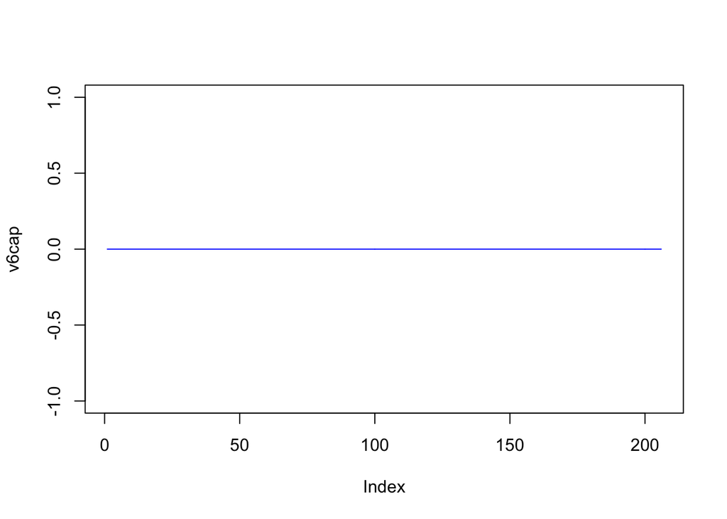

## Actividad para el ASN 6503

- Nombre organización: **Axtel, S.A.B. de C.V.**
- Promedio de actividad IPv6 ultimos 30 dias: 0.00375 %
- Máximo de actividad IPv6 ultimos 30 dias: 0.01 %
- Promedio de actividad IPv6 ultimos 360 dias: 0.00115789473684211 %
- Máximo de actividad IPv6 ultimos 360 dias: 0.01 %

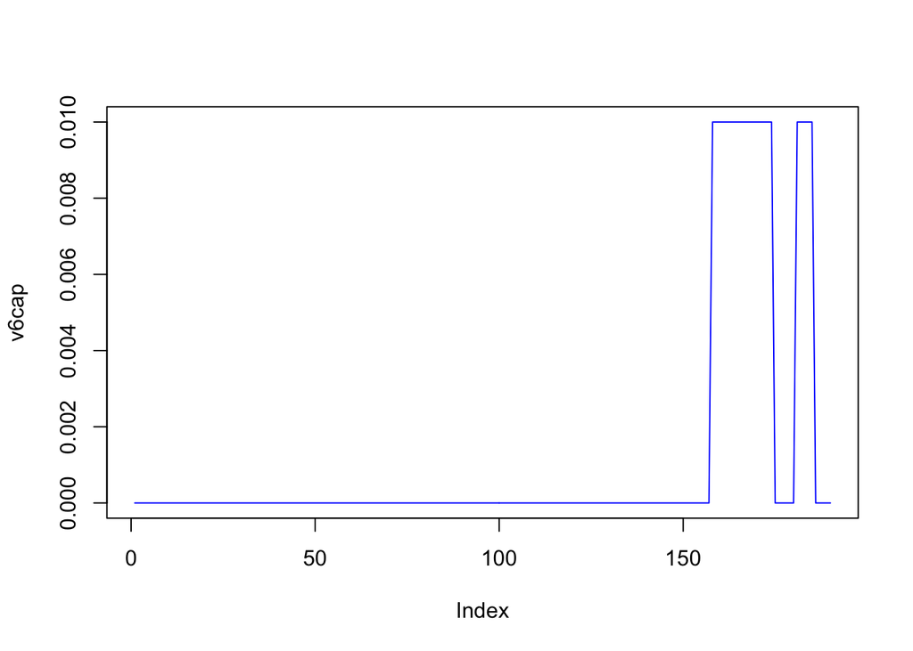

## Actividad para el ASN 28554

- Nombre organización: **Cablemas Telecomunicaciones SA de C**
- Promedio de actividad IPv6 ultimos 30 dias: 0 %
- Máximo de actividad IPv6 ultimos 30 dias: 0 %
- Promedio de actividad IPv6 ultimos 360 dias: 1e-04 %
- Máximo de actividad IPv6 ultimos 360 dias: 0.01 %

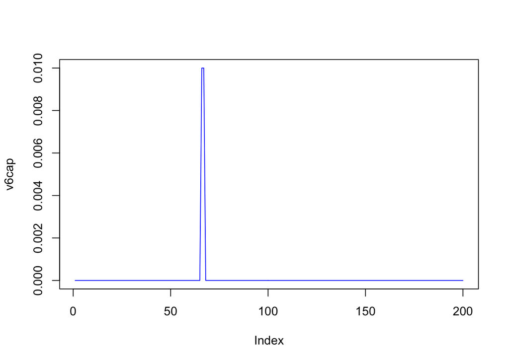

## Actividad para el ASN 28403

- Nombre organización: **RadioMovil Dipsa, S.A. de C.V.**
- Promedio de actividad IPv6 ultimos 30 dias: 0.02 %
- Máximo de actividad IPv6 ultimos 30 dias: 0.02 %
- Promedio de actividad IPv6 ultimos 360 dias: 0.00136150234741784 %
- Máximo de actividad IPv6 ultimos 360 dias: 0.02 %

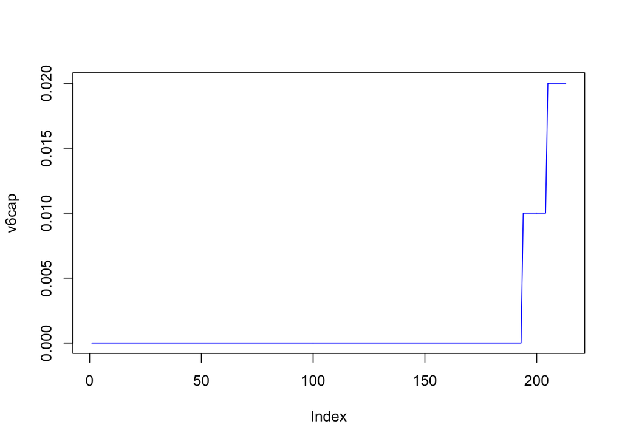

## Actividad para el ASN 28545

- Nombre organización: **Cablemas Telecomunicaciones SA de C**
- Promedio de actividad IPv6 ultimos 30 dias: 0 %
- Máximo de actividad IPv6 ultimos 30 dias: 0 %
- Promedio de actividad IPv6 ultimos 360 dias: 0.000788177339901478 %
- Máximo de actividad IPv6 ultimos 360 dias: 0.01 %

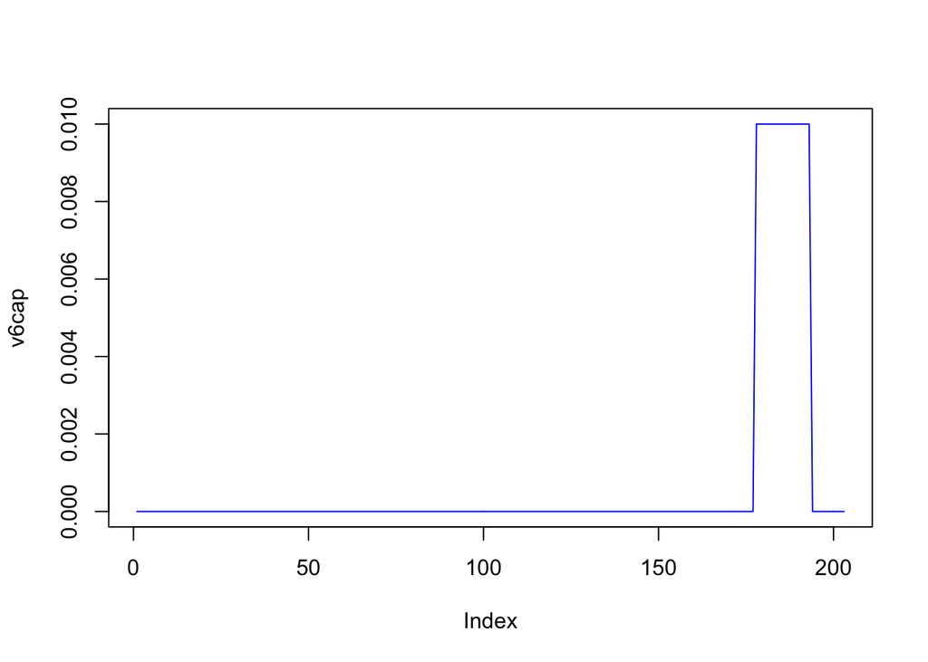